# Generative Deep Learning

**Note: For the walk-through of Variational Autoencoders (VAEs), go to the last section of the MNIST notebook.**

# 1. Text Generation with LSTMs

We first train an LSTM so that it's able to predict the next token (or next few tokens) in a sequence using an initial string of text (called the conditioning data). We then update the input to include the predicted text and predict the token after. By stringing these predicted tokens together, we generate a text sequence.

The predictions of the LSTM are a discrete probability distribution over all tokens. We can sample from a closely-related sampling distribution which is characterized by `temperature`.

```
def reweight_distribution(original_distribution, temperature=0.5):
    distribution = np.log(original_distribution) / temperature
    distribution = np.exp(distribution)
    return distribution / np.sum(distribution)
```

When `temperature = 0`, the text generator will always return the most likely token. This will result in text that has very little entropy but is not very interesting. As the temperature goes higher, the text becomes more interesting, but it becomes more likely that the text stops making sense or does not follow the norms of the English language.

We shall train our model on the texts of Nietzsche.

```python
import numpy as np
import random
import sys
import scipy
import scipy.misc
import imageio
from matplotlib import pyplot as plt
import time
import os

from keras.preprocessing import image
import keras
from keras import layers

path = keras.utils.get_file('nietzsche.txt', origin='https://s3.amazonaws.com/text-datasets/nietzsche.txt')
text = open(path).read().lower()
print('Corpus lengh:', len(text))
```

```
Corpus lengh: 600893
```

Let us have a look at a sample of the text.

```python
text[10:360]
```

```
'supposing that truth is a woman--what then? is there not ground\nfor suspecting that all philosophers, in so far as they have been\ndogmatists, have failed to understand women--that the terrible\nseriousness and clumsy importunity with which they have usually paid\ntheir addresses to truth, have be…
```

We now extract partially overlapping sequences of length `maxlen`. The sequneces are then one-hot encoded and packed into a Numpy array (shape `(sequences, maxlen, unique_characters)`). In addition, we prepare an array `y` that contain the one-hot-encoded characters that come after each extracted sequence.

```python
maxlen = 60  # sequence of 60 characters
step = 3  # controls the amount of overlap between successive sampled sequences

sentences = []  # stores the extracted sequences
next_chars = []  # stores the targets
for i in range(0, len(text) - maxlen, step):
    sentences.append(text[i:(i + maxlen)])
    next_chars.append(text[i + maxlen])

print('Number of sentences:', len(sentences))

chars = sorted(list(set(text)))  # list of unique characters in the corpus
print('Number of unique characters:', len(chars))
char_indices = dict((char, chars.index(char)) for char in chars)  # dict maps tokens to their index in 'chars'

print('One hot encoding...')
x = np.zeros((len(sentences), maxlen, len(chars)), dtype=np.bool)
y = np.zeros((len(sentences), len(chars)), dtype=np.bool)
for i, sentence in enumerate(sentences):
    for t, char in enumerate(sentence):
        x[i, t,char_indices[char]] = 1
    y[i, char_indices[next_chars[i]]] = 1

print('Finished!')
```

```
Number of sentences: 200278
Number of unique characters: 57
One hot encoding...
Finished!
```

We can now define the model.

```python
model = keras.models.Sequential()
model.add(layers.LSTM(128, input_shape=(maxlen, len(chars))))
model.add(layers.Dense(len(chars), activation='softmax'))
model.summary()
```

```
Model: "sequential_1"
_________________________________________________________________
Layer (type)                 Output Shape              Param #
=================================================================
lstm_1 (LSTM)                (None, 128)               95232
_________________________________________________________________
dense_1 (Dense)              (None, 57)                7353
=================================================================
Total params: 102,585
Trainable params: 102,585
Non-trainable params: 0
_________________________________________________________________
```

As the targets are one hot encoded, we use `categorical_crossentropy` as the loss.

```python
optimizer = keras.optimizers.RMSprop(lr=0.01)
model.compile(loss='categorical_crossentropy', optimizer=optimizer)
```

Let us develop a function that reweights the original probability distribution from the model according to a chosen temperature.

```python
def sample(preds, temperature=1.0):
    preds = np.asarray(preds).astype('float64')
    preds = np.log(preds) / temperature
    exp_preds = np.exp(preds)
    preds = exp_preds / np.sum(exp_preds)
    probas = np.random.multinomial(1, preds, 1)
    return np.argmax(probas)
```

```python
for epoch in range(1, 60):
    print('epoch', epoch)
    model.fit(x, y, batch_size=128, epochs=1)  # fits the model for one iteraton of the data

    if epoch in [19, 59]:

        # we randomly select the conditioning data (or string) use to initialize the generated text
        start_index = random.randint(0, len(text) - maxlen - 1)
        generated_text = text[start_index:(start_index + maxlen)]
        print('--- Generating with seed: "' + generated_text + '"')

        for temperature in [0.2, 0.5, 1.0]:
            print('------ temperature: ', temperature)
            sys.stdout.write(generated_text)

            # generate 400 characters from the seed text
            for i in range(400):

                # one-hot encode the generated_text
                sampled = np.zeros((1, maxlen, len(chars)))
                for t, char in enumerate(generated_text):
                    sampled[0, t, char_indices[char]] = 1

                # sample the next character given the generated_text
                preds = model.predict(sampled, verbose=0)[0]
                next_index = sample(preds, temperature)
                next_char = chars[next_index]

                generated_text += next_char  # append predicted char to text segment
                generated_text = generated_text[1:]  # ... and trim of the last segment

                sys.stdout.write(next_char)
```

```
epoch 1
epoch 2
epoch 3
epoch 4
epoch 5
epoch 6
epoch 7
epoch 8
epoch 9
epoch 10
epoch 11
epoch 12
epoch 13
epoch 14
epoch 15
epoch 16
epoch 17
epoch 18
epoch 19
--- Generating with seed: "rmined from the effect and _after_ the
effect: all this, too"
------ temperature:  0.2
rmined from the effect and _after_ the
effect: all this, too has the soul.


111
t the suffering of the conditions of the conditions of the fact and the same will be a soriety and the same with a soul, and some the senses a soriety and the senses and something to the suffering of the same the soul, the suns of the contrary and some the same in the same and some in the condition …
ience of the fact that the sentiment and some the soul, in them and discouls and with is oneself--a scientific to the fact of the conduct the most day and life of the discounting of the also for the father onescation of the senses into the superity has an endood in the last from the exercising of th…
ct and modern impression of the exceptions of the part of the gaves" them either just athebrowified poordned of his cost, but sad all the suskcocrals has with one cause for a siquicun before beneath
and demiyrity with a compulsits of risunderingly fool of the jepinates
itself to cearous
most perpocration (would possible,

thuck extence, and overreasic, under-stronger to operating longe. he is, to be that
they themselves among deteriorations of the being weepoch 20
epoch 21
epoch 22
epoch 23
epoch 24
```

[output cut: 25 more lines]

```
epoch 50
epoch 51
epoch 52
epoch 53
epoch 54
epoch 55
epoch 56
epoch 57
epoch 58
epoch 59
--- Generating with seed: "t the objects of the
religious, moral, aesthetic and logical"
------ temperature:  0.2
t the objects of the
religious, moral, aesthetic and logical to the senses to be distinguished, and the senses to be long and soul and soul-anduded the senses to the belief in the same things and soul in the strength and self-conscience of the sense of the same thing of the same thing of the same things are something an…
```

```
 be a so------ temperature:  0.5
and self-contrare the most distrust of the senses to be a soul-having as an existing or history of the seem the abstracted by the senses even and lower conscience and the interest of the responsibility of such a soul. the same time a soul, the more all the
soul in the same things the all things and old his conscience, the same things and the result to the intellectual power of the self-kin the greates and not one believe the serity, and distinguism, in the------ temperature:  1.0
ates and not one believe the serity, and distinguism, in the opposition to readily and such are to make no
longer in still indifferentness inthither--it remuded leads to book--"something looks floom: the
most helpcita labtes his
souther his explainalty, as slomen, and for the as
truth, which is ghem the charn is always called ruins also adorisy innocents, every virtue"--so far
tiess eternal thing, to the
family and certainty that this assumption are suffer
```

# 2. DeepDream

Recall we visualized filters by performing gradient ascent on the input of the covnet. The loss is chosen specifically so that the algorithm maximizes the activation of a chosen covnet filter. DeepDream is very similar, though it has a few differences:

- we maximimize the activation of entire layers (rather than a specific filter)
- we start from an exising image, causing the algorithm to distort elements of the image in an artistic fashion. In contrast, the feature visualization approach started with a noisy input.
- the input images are processed at different scales (called octaces), which improves the quality of the images.

We'll use the `inception_v3` model to produce visualizations

```python
from keras.applications import inception_v3
from keras import backend as K

K.set_learning_phase(0)  # disables trainings
model = inception_v3.InceptionV3(weights='imagenet', include_top=False)  # exclude the classier on top
```

We can then define a loss. We'll maximize the weighted sum of the L2 norm of the activations of a set of high-level layers.

```python
layer_contributions = {'mixed2': 0.2, 'mixed3': 3., 'mixed4': 2., 'mixed5': 1.5}

layer_dict = dict([(layer.name, layer) for layer in model.layers])  # dict maps layer names to instances

# define the loss as the weighting of the specified layer's activations
loss = K.variable(0.)
for layer_name in layer_contributions:
    coeff = layer_contributions[layer_name]
    activation = layer_dict[layer_name].output

    scaling = K.prod(K.cast(K.shape(activation), 'float32'))
    loss = loss + coeff * K.sum(K.square(activation[:, 2: -2, 2: -2, :])) / scaling
```

We can then implement gradient ascent on this loss.

```python
dream = model.input  # will hold the generated image

grads = K.gradients(loss, dream)[0]  # calculates the gradient of dream wrt loss
grads /= K.maximum(K.mean(K.abs(grads)), 1e-7)  # normalizes the gradient

outputs = [loss, grads]
fetch_loss_and_grads = K.function([dream], outputs)  # define function to retrieve outputs given an input

def eval_loss_and_grads(x):
    outs = fetch_loss_and_grads([x])
    loss_value = outs[0]
    grad_values = outs[1]
    return loss_value, grad_values

def gradient_ascent(x, iterations, step, max_loss=None):
    for i in range(iterations):
        loss_value, grad_values = eval_loss_and_grads(x)
        if max_loss is not None and loss_value > max_loss:
            break
        print('... Loss value at', i, ': ', loss_value)
        x += step * grad_values

    return x
```

DeepDream also requires a list of *scales* (or *octaves*) at which to process the images. Each successive scale is 40% larger than the previous one. In each scale, we run gradient ascent to maximize the loss and then upscale the resulting image by 40%. We then reinject the lost details (drawn from the original image) back to the upscaled version. To start, we'll define some auxillary functions that will help with the future analysis.

```python
def resize_img(img, size):
    img = np.copy(img)
    factors = (1, float(size[0]) / img.shape[1], float(size[1]) / img.shape[2], 1)
    return scipy.ndimage.zoom(img, factors, order=1)

def save_img(img, fname):
    pil_img = deprocess_image(np.copy(img))
    #scipy.misc.imsave(fname, pil_img)
    imageio.imwrite(fname, pil_img)

# formats picture into tensor that a convnet can process
def preprocess_image(image_path):
    img = image.load_img(image_path)
    img = image.img_to_array(img)
    img = np.expand_dims(img, axis=0)
    img = inception_v3.preprocess_input(img)
    return img

# util function to convert tensor into a valid image
def deprocess_image(x):
    if K.image_data_format() == 'channels_first':
        x = x.reshape((3, x.shape[2], x.shape[3]))
        x = x.transpose((1, 2, 0))
    else:
        x = x.reshape((x.shape[1], x.shape[2], 3))

    # undoes preprocessing that is performed by convnet
    x /= 2.
    x += 0.5
    x *= 255.
    x = np.clip(x, 0, 255).astype('uint8')
    return x
```

Given the auxilary functions, we can now implement DeepDream.

```python
# DeepDream Hyperparameters
step = 0.01  # gradient ascent step size
num_octave = 3  # number of scales at which to run gradient ascent
octave_scale = 1.4  # size ratio between scales
iterations = 20  # number of ascent steps to run at each scale
max_loss = 10.

base_image_path = '/home/d869321/Data/CatsVsDogsSmall/creative_commons_elephant.jpg'  # image to deepdream
#base_image_path = '/home/d869321/Data/CatsVsDogsSmall/train/dogs/dog.6.jpg'
img = preprocess_image(base_image_path)  # loads base image into numpy array

# prepare a list of shape tuples defining the different scales at which to run gradient descent
original_shape = img.shape[1:3]
successive_shapes = [original_shape]
for i in range(1, num_octave):
    shape = tuple([int(dim / (octave_scale ** i)) for dim in original_shape])
    successive_shapes.append(shape)

successive_shapes = successive_shapes[::-1]  # reverses the list of tuples so now in increasing order

original_img = np.copy(img)
shrunk_original_img = resize_img(img, successive_shapes[0])  # resizes image to smallest scale

for shape in successive_shapes:
    print('Processing image shape ', shape)
    img = resize_img(img, shape)  # scales us the dream image
    # runs gradient ascent to add dream elements to image
    img = gradient_ascent(img, iterations=iterations, step=step, max_loss=max_loss)
    upscaled_shrunk_original_img = resize_img(shrunk_original_img, shape)  # scales up smaller version
    same_size_original = resize_img(original_img, shape)  # converts original image to same scale as dream
    lost_detail = same_size_original - upscaled_shrunk_original_img

    img += lost_detail  # reinjects lost detail into dream
    shrunk_original_img = resize_img(original_img, shape)
    save_img(img, fname='/home/d869321/PycharmProjects/neuralExamples/DeepDreamImages/elephants_deepdream.jpg')
    #save_img(img, fname='/home/d869321/PycharmProjects/neuralExamples/DeepDreamImages/dog_deepdream.jpg')
```

```
Processing image shape  (201, 301)
... Loss value at 0 :  1.7137637
... Loss value at 1 :  2.2210107
... Loss value at 2 :  2.9586897
... Loss value at 3 :  3.6079373
... Loss value at 4 :  4.213902
... Loss value at 5 :  4.880236
... Loss value at 6 :  5.429316
... Loss value at 7 :  5.954515
... Loss value at 8 :  6.4450183
... Loss value at 9 :  6.895051
... Loss value at 10 :  7.3563137
... Loss value at 11 :  7.8582916
... Loss value at 12 :  8.252004
... Loss value at 13 :  8.639093
... Loss value at 14 :  9.1298895
... Loss value at 15 :  9.523674
... Loss value at 16 :  9.923468
Processing image shape  (281, 421)
... Loss value at 0 :  2.8267932
... Loss value at 1 :  4.176048
... Loss value at 2 :  5.3137183
... Loss value at 3 :  6.2465396
... Loss value at 4 :  7.0841055
... Loss value at 5 :  7.849708
... Loss value at 6 :  8.495862
... Loss value at 7 :  9.182504
... Loss value at 8 :  9.766819
Processing image shape  (394, 590)
... Loss value at 0 :  2.8503995
... Loss value at 1 :  4.1461496
... Loss value at 2 :  5.2681384
... Loss value at 3 :  6.2243924
... Loss value at 4 :  7.1195874
... Loss value at 5 :  7.93332
... Loss value at 6 :  8.79406
... Loss value at 7 :  9.547542
```

We can then view both the original and the genertated image.

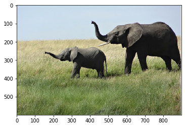

```python
img_path = '/home/d869321/Data/CatsVsDogsSmall/creative_commons_elephant.jpg'

img = image.load_img(img_path, target_size=(600,899))
img_tensor = image.img_to_array(img)
img_tensor = np.expand_dims(img_tensor, axis=0)
img_tensor /= 255.

plt.imshow(img_tensor[0])
```

[figure not shown]

```python
img_gen_path = '/home/d869321/PycharmProjects/neuralExamples/DeepDreamImages/elephants_deepdream.jpg'

img_gen = image.load_img(img_gen_path, target_size=(600,899))
img_gen_tensor = image.img_to_array(img_gen)
img_gen_tensor = np.expand_dims(img_gen_tensor, axis=0)
img_gen_tensor /= 255.

plt.imshow(img_gen_tensor[0])
```

# 3. Neural style transfer

In a convnet, we expect the high layers to represent the content of an image whilst the earlier layers will contain more local information and hence represent the style of an image. We can thus seek to generate an image whose content is similar to one image (the `target_image`), but whose style is similar to another image (the `style_reference_image`) using the following loss:

```
loss = distance(style(style_reference_image) - style(generated_image))
     + distance(content(target_image) - content(generated_image))
```

We follow the following steps:

- set up a network that calulates VGG19 layer activations for the `style_reference_image`, the `target_image` and the generated image
- use the layer activations computed over these three images to define the loss
- use gradient descent to vary the generated image in order to minimize this loss function

Let us start by defining the paths to the style-reference image and the target image.

```python
from keras.preprocessing.image import load_img, img_to_array
from keras.applications import vgg19
```

```python
#target_image_path = '/home/d869321/Data/CatsVsDogsSmall/dog.23.jpg'
target_image_path = '/home/d869321/Data/CatsVsDogsSmall/creative_commons_elephant.jpg'
style_reference_image_path = '/home/d869321/Data/CatsVsDogsSmall/1-style.jpg'

# make generated image mantain same aspect ratio as original, but have width 400px
width, height = load_img(target_image_path).size
img_height = 400
img_width = int(width * img_height / height)
```

We need some auxillary functions that load, preprocess and postprocess the images that go in and out of the convnet.

```python
def preprocess_image(image_path):
    img = load_img(image_path, target_size=(img_height, img_width))
    img = img_to_array(img)
    img = np.expand_dims(img, axis=0)
    img = vgg19.preprocess_input(img)
    return img

def deprocess_image(x):
    # reverse a transformation done by vgg19.preprocess_input
    x[:, :, 0] += 103.939
    x[:, :, 1] += 116.779
    x[:, :, 2] += 123.68

    x = x[:, :, ::-1]  # convert image from 'BGR' to 'RGB' (part of reversal of vgg preprocessing)
    x = np.clip(x, 0, 255).astype('uint8')
    return x
```

We setup the VGG19 network to take as input three images: the style-reference image, the target image and a placeholder that will contain the generated image.

```python
target_image = K.constant(preprocess_image(target_image_path))
style_reference_image = K.constant(preprocess_image(style_reference_image_path))
combination_image = K.placeholder((1, img_height, img_width, 3))  # placeholder for generated image

input_tensor = K.concatenate([target_image, style_reference_image, combination_image], axis=0)

model = vgg19.VGG19(input_tensor=input_tensor, weights='imagenet', include_top=False)  # use convolution base
print('Model loaded.')
```

```
Model loaded.
```

At this point, the neural network will show the activations for the `target_image`, the `style_reference_image` and the `combination_image`. We need to define a loss that we minimize by altering the `combination_image`.

We start by defining the content loss and style loss (this will requre an auxilary function to compute the Gram matrix of the input). The content loss will use only the upper layer of the convolutional base (`block5_conv2`) whilst the style loss will use a list of layers that span both low-level and high-level layers.

```python
# define the content loss. base = target_image, combination = generated image
def content_loss(base, combination):
    return K.sum(K.square(combination - base))

# compute Gram matrix of x. This will map the correlations found in x.
def gram_matrix(x):
    features = K.batch_flatten(K.permute_dimensions(x, (2, 0, 1)))  # moves the nFilter dimension to be first
    gram = K.dot(features, K.transpose(features))  # results in a nFilter x nFilter matrix
    return gram

# define style loss. style = style reference image. combination = generated image
def style_loss(style, combination):
    S = gram_matrix(style)
    C = gram_matrix(combination)
    channels = 3
    size = img_height * img_width
    return K.sum(K.square(S - C)) / (4. * (channels ** 2) * (size ** 2))
```

We also define the *total variation loss*, which operates on the pixels of the generated image. This loss will encourages spatial continuity in the generated image.

```python
def total_variation_loss(x):
    a = K.square(x[:, :img_height - 1, :img_width - 1, :] - x[:, 1:, :img_width - 1, :])
    b = K.square(x[:, :img_height - 1, :img_width - 1, :] - x[:, :img_height - 1, 1:, :])
    return K.sum(K.pow(a + b, 1.25))
```

We then minimize a weighted average of these three losses.

```python
outputs_dict = dict([(layer.name, layer.output) for layer in model.layers])  # dict maps layers to activations
content_layer = 'block5_conv2'  # upper-most layer
style_layers = ['block1_conv1', 'block2_conv1', 'block3_conv1', 'block4_conv1', 'block5_conv1']
# define weights for three loss components
total_variation_weight = 1e-4
style_weight = 1.
content_weight = 0.025

# add the content loss
loss = K.variable(0.)  # we'll add all loss components to this variable
layer_features = outputs_dict[content_layer]
# note first dimension of layer_features tells if target_image, style_reference_image or combination_image
target_image_features = layer_features[0, :, :, :]  # dim = (which image?, xAxis, yAxis, numFeatureMaps)
combination_features = layer_features[2, :, :, :]
loss = loss + content_weight * content_loss(target_image_features, combination_features)

# adds the style loss for each specified layer
for layer_name in style_layers:
    layer_features = outputs_dict[layer_name]
    style_reference_features = layer_features[1, :, :, :]
    combination_features = layer_features[2, :, :, :]
    sl = style_loss(style_reference_features, combination_features)
    loss = loss + (style_weight / len(style_layers)) * sl

# adds the variation loss
loss = loss + total_variation_weight * total_variation_loss(combination_image)
```

We shall perform gradient descent using the L-BFGS algorithm. It comes packaged with SciPy, but it can only applied to flat vectors (instead of the 3D images we are using). In addition, SciPy insists that the value of the loss and the value of the gradient be passed as two separate functions. To bypass this inefficiency, we setup an `Evaluator` class to calculate the loss and gradient at once. This class shall return the loss when called whilst caching the gradient for the next call.

```python
grads = K.gradients(loss, combination_image)[0]  # gradient of generated image wrt loss
fetch_loss_and_grads = K.function([combination_image], [loss, grads])  # fn to fetch values of loss, grad

# class will wrap fetch_loss_and_grads so that losses and grads can be retrieved via 2 separate method calls
class Evaluator(object):

    def __init__(self):
        self.loss_value = None
        self.grads_values = None

    def loss(self, x):
        assert self.loss_value is None
        x = x.reshape((1, img_height, img_width, 3))
        outs = fetch_loss_and_grads([x])
        loss_value = outs[0]
        grad_values = outs[1].flatten().astype('float64')
        self.loss_value = loss_value
        self.grad_values = grad_values
        return self.loss_value

    def grads(self, x):
        assert self.loss_value is not None
        grad_values = np.copy(self.grad_values)
        self.loss_value = None
        self.grad_values = None
        return grad_values

evaluator = Evaluator()
```

```python
from scipy.optimize import fmin_l_bfgs_b

result_prefix = 'NeuralTransferImages/my_result'
iterations = 20

x = preprocess_image(target_image_path)  # the initial state x is set to target image
x = x.flatten()  # algorithm can only process flat vectors
for i in range(iterations):
    print('Start of iteration ', i)
    start_time = time.time()
    # run L-BFGS over pixels of generated image to minimize the loss. Note loss and grad passed separately
    x, min_val, info = fmin_l_bfgs_b(evaluator.loss, x, fprime=evaluator.grads, maxfun=20)
    print('Current loss value: ', min_val)
    img = x.copy().reshape((img_height, img_width, 3))
    img = deprocess_image(img)

    # save the image
    fname = result_prefix + '_at_iteration_%d.png' % i
    imageio.imwrite(fname, img)

    print('Image saved as ', fname)
    end_time = time.time()
    print('Iteration %d completed in %ds' % (i, end_time - start_time))
```

```
Start of iteration  0
Current loss value:  1228720500.0
Image saved as  NeuralTransferImages/my_result_at_iteration_0.png
Iteration 0 completed in 109s
Start of iteration  1
Current loss value:  489167070.0
Image saved as  NeuralTransferImages/my_result_at_iteration_1.png
Iteration 1 completed in 115s
Start of iteration  2
Current loss value:  327983970.0
Image saved as  NeuralTransferImages/my_result_at_iteration_2.png
Iteration 2 completed in 110s
Start of iteration  3
Current loss value:  246770820.0
Image saved as  NeuralTransferImages/my_result_at_iteration_3.png
Iteration 3 completed in 110s
Start of iteration  4
Current loss value:  202405360.0
Image saved as  NeuralTransferImages/my_result_at_iteration_4.png
Iteration 4 completed in 110s
Start of iteration  5
Current loss value:  172226030.0
Image saved as  NeuralTransferImages/my_result_at_iteration_5.png
Iteration 5 completed in 110s
Start of iteration  6
Current loss value:  149054020.0
Image saved as  NeuralTransferImages/my_result_at_iteration_6.png
Iteration 6 completed in 110s
Start of iteration  7
Current loss value:  129647120.0
Image saved as  NeuralTransferImages/my_result_at_iteration_7.png
Iteration 7 completed in 110s
Start of iteration  8
Current loss value:  117575740.0
Image saved as  NeuralTransferImages/my_result_at_iteration_8.png
Iteration 8 completed in 110s
Start of iteration  9
Current loss value:  108732440.0
Image saved as  NeuralTransferImages/my_result_at_iteration_9.png
Iteration 9 completed in 110s
```

[output cut: 25 more lines]

```
Current loss value:  73485576.0
Image saved as  NeuralTransferImages/my_result_at_iteration_16.png
Iteration 16 completed in 110s
Start of iteration  17
Current loss value:  70790136.0
Image saved as  NeuralTransferImages/my_result_at_iteration_17.png
Iteration 17 completed in 110s
Start of iteration  18
Current loss value:  67391340.0
Image saved as  NeuralTransferImages/my_result_at_iteration_18.png
Iteration 18 completed in 110s
Start of iteration  19
Current loss value:  65089690.0
Image saved as  NeuralTransferImages/my_result_at_iteration_19.png
Iteration 19 completed in 110s
```

We can then examine the resulting images. Here is the original.

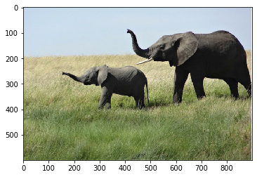

```python
img_path = '/home/d869321/Data/CatsVsDogsSmall/creative_commons_elephant.jpg'

img = image.load_img(img_path, target_size=(600,899))
img_tensor = image.img_to_array(img)
img_tensor = np.expand_dims(img_tensor, axis=0)
img_tensor /= 255.

plt.imshow(img_tensor[0])
```

Here is the image with Style Transfer.

[figure not shown]

```python
img_path = '/home/d869321/PycharmProjects/neuralExamples/NeuralTransferImages/my_result_at_iteration_19.png'

img = image.load_img(img_path, target_size=(600,899))
img_tensor = image.img_to_array(img)
img_tensor = np.expand_dims(img_tensor, axis=0)
img_tensor /= 255.

plt.imshow(img_tensor[0])
```

# 4. Generative Adversarial Networks (GANs)

GANs are an alternative to VAEs for learning latent space of images. A GAN consists of a *generator* network that takes a vector from the latent space and decodes it into a synthetic image and a *discriminator* network, which takes an input and predicts whether it is real or was produced by the *generator* network. The training continues until the *discriminator* network can't tell the difference between the real and synthetic images.

The GAN chains the generator and discriminator together: `gan(x) = discriminator(generator(x))` where `x` is a sampled point from the latent space. The discriminator is trained using a mix of real/synthetic images together with their label. The discriminator is trained to minimize the binary_crossentropy whilst the generator attempts to maximize the binary_crossentropy.

The optimization minimum isn't fixed as the loss landscape changes as the two networks are updated. This makes GANs notoriously difficult to train. Here are some tricks:

- use `tanh` as the last activation of the generator (instead of `sigmoid`)
- sample points from the latent space using a normal distribution (instead of a uniform distribution)
- add randomness by firstly using dropout in the discriminator and secondly adding random noise to the labels of the discriminator
- Though sparse gradients are helpful for most forms of deeplearning, they hurt GANs. Thus, instead of max pooling, use a strided convolution for downsampling and use a `LeakyReLU` activation (which enables small negative values) instead of a `ReLU` activation.
- ensure the kernel size is divisible by the stride size when using `Conv2DTranspose` (for image upsampling) or `Conv2D` in both networks.

We shall apply a GAN to CIFAR10, a dataset of 50,000 32xx32 RGB images belonging to 10 classes (5,000 images per class). TO make things easier, we'll focus on the *frog* class.

## 4.1. The Generator

The generator may get stuck with synthetic images that look like noise. Often applying dropout to both networks helps to avoid this.

```python
latent_dim = 32
height = 32
width = 32
channels = 3

generator_input = keras.Input(shape=(latent_dim,))
# transforms the input into a 16x16 128-channel feature map
x = layers.Dense(128 * 16 * 16)(generator_input)
x = layers.LeakyReLU()(x)
x = layers.Reshape((16, 16, 128))(x)

x = layers.Conv2D(256, 5, padding='same')(x)
x = layers.LeakyReLU()(x)
# upsample image to 32x32
x = layers.Conv2DTranspose(256, 4, strides=2, padding='same')(x)
x = layers.LeakyReLU()(x)

x = layers.Conv2D(256, 5, padding='same')(x)
x = layers.LeakyReLU()(x)
x = layers.Conv2D(256, 5, padding='same')(x)
x = layers.LeakyReLU()(x)
# produces a 32x32 3-channel feature map (shape of CIFAR10 image)
x = layers.Conv2D(channels, 7, activation='tanh', padding='same')(x)
generator = keras.models.Model(generator_input, x)  # instantiates generator model
generator.summary()
```

```
Model: "model_1"
_________________________________________________________________
Layer (type)                 Output Shape              Param #
=================================================================
input_3 (InputLayer)         (None, 32)                0
_________________________________________________________________
dense_2 (Dense)              (None, 32768)             1081344
_________________________________________________________________
leaky_re_lu_1 (LeakyReLU)    (None, 32768)             0
_________________________________________________________________
reshape_1 (Reshape)          (None, 16, 16, 128)       0
_________________________________________________________________
conv2d_95 (Conv2D)           (None, 16, 16, 256)       819456
_________________________________________________________________
leaky_re_lu_2 (LeakyReLU)    (None, 16, 16, 256)       0
_________________________________________________________________
conv2d_transpose_1 (Conv2DTr (None, 32, 32, 256)       1048832
_________________________________________________________________
leaky_re_lu_3 (LeakyReLU)    (None, 32, 32, 256)       0
_________________________________________________________________
conv2d_96 (Conv2D)           (None, 32, 32, 256)       1638656
_________________________________________________________________
leaky_re_lu_4 (LeakyReLU)    (None, 32, 32, 256)       0
_________________________________________________________________
conv2d_97 (Conv2D)           (None, 32, 32, 256)       1638656
_________________________________________________________________
leaky_re_lu_5 (LeakyReLU)    (None, 32, 32, 256)       0
_________________________________________________________________
conv2d_98 (Conv2D)           (None, 32, 32, 3)         37635
=================================================================
Total params: 6,264,579
Trainable params: 6,264,579
Non-trainable params: 0
_________________________________________________________________
```

## 4.2. The Discriminator

```python
discriminator_input = layers.Input(shape=(height, width, channels))
x = layers.Conv2D(128, 3)(discriminator_input)
x = layers.LeakyReLU()(x)
x = layers.Conv2D(128, 4, strides=2)(x)
x = layers.LeakyReLU()(x)
x = layers.Conv2D(128, 4, strides=2)(x)
x = layers.LeakyReLU()(x)
x = layers.Conv2D(128, 4, strides=2)(x)
x = layers.LeakyReLU()(x)
x = layers.Flatten()(x)
x = layers.Dropout(0.4)(x)  # this dropout layer is very important to allow convergence to good solns
x = layers.Dense(1, activation='sigmoid')(x)  # rather use tanh???

discriminator = keras.models.Model(discriminator_input, x)  # instantiates the discriminatior
discriminator.summary()
```

```
Model: "model_2"
_________________________________________________________________
Layer (type)                 Output Shape              Param #
=================================================================
input_4 (InputLayer)         (None, 32, 32, 3)         0
_________________________________________________________________
conv2d_99 (Conv2D)           (None, 30, 30, 128)       3584
_________________________________________________________________
leaky_re_lu_6 (LeakyReLU)    (None, 30, 30, 128)       0
_________________________________________________________________
conv2d_100 (Conv2D)          (None, 14, 14, 128)       262272
_________________________________________________________________
leaky_re_lu_7 (LeakyReLU)    (None, 14, 14, 128)       0
_________________________________________________________________
conv2d_101 (Conv2D)          (None, 6, 6, 128)         262272
_________________________________________________________________
leaky_re_lu_8 (LeakyReLU)    (None, 6, 6, 128)         0
_________________________________________________________________
conv2d_102 (Conv2D)          (None, 2, 2, 128)         262272
_________________________________________________________________
leaky_re_lu_9 (LeakyReLU)    (None, 2, 2, 128)         0
_________________________________________________________________
flatten_1 (Flatten)          (None, 512)               0
_________________________________________________________________
dropout_1 (Dropout)          (None, 512)               0
_________________________________________________________________
dense_3 (Dense)              (None, 1)                 513
=================================================================
Total params: 790,913
Trainable params: 790,913
Non-trainable params: 0
_________________________________________________________________
```

We can then compile the model.

```python
# clipping is useful and decay stabilizes the training
discriminator_optimizer = keras.optimizers.RMSprop(lr=0.0008, clipvalue=1.0, decay=1e-8)
discriminator.compile(optimizer=discriminator_optimizer, loss='binary_crossentropy')
```

## 4.3. The Adversarial Network

We now chain the generator and the discriminator. When training `gan`, we wish to freeze the training of the discriminator.

```python
discriminator.trainable = False  # dont want to train the discriminator within the GAN. Focus on generator.

gan_input = keras.Input(shape=(latent_dim,))
gan_output = discriminator(generator(gan_input))
gan = keras.models.Model(gan_input, gan_output)

gan_optimizer = keras.optimizers.RMSprop(lr=0.0004, clipvalue=1.0, decay=1e-8)
gan.compile(optimizer=gan_optimizer, loss='binary_crossentropy')
```

## 4.4 Training the GAN

The training loop is as follows:

1. Draw random points in the latent space
2. Generate images with `generator`
3. Mix the synthetic images with the real ones
4. Train `discriminator` using these mixed images and their corresponding labels
5. Draw new random point in latent space
6. Train `gan` with random vectors whose corresponding labels are "real image" As the discriminator is frozen in the `gan`, only the generator will have its weights updated so that the resulting images are more likely to fool the current discriminator

Let's get the data and normalize it.

```python
(x_train, y_train), (_, _) = keras.datasets.cifar10.load_data()

x_train = x_train[y_train.flatten() == 6]  # select just the frog images
# normalize the images
x_train = x_train.reshape((x_train.shape[0],) + (height, width, channels)).astype('float32') / 255.
```

We can now train the model.

```python
iterations = 10000
batch_size = 20
save_dir = '/home/d869321/PycharmProjects/neuralExamples/GANImages'

start = 0
for step in range(iterations):
    random_latent_vectors = np.random.normal(size=(batch_size, latent_dim))  # get random pnts in latent space

    # generate batch_size images and combine with batch_size real images
    generated_images = generator.predict(random_latent_vectors)  # decodes them to synthetic images
    stop = start + batch_size
    real_images = x_train[start:stop]
    combined_images = np.concatenate([generated_images, real_images])
    labels = np.concatenate([np.ones((batch_size, 1)), np.zeros((batch_size, 1))])  # "0"=real, "1"=fake
    labels += 0.05 * np.random.random(labels.shape)  # important! adding noise helps with training

    d_loss = discriminator.train_on_batch(combined_images, labels)  # train the discriminator

    random_latent_vectors = np.random.normal(size=(batch_size, latent_dim))  # get random pnts in latent space

    misleading_targets = np.zeros((batch_size, 1))  # lie and say all the images generated within GAN are real

    a_loss = gan.train_on_batch(random_latent_vectors, misleading_targets)  # train the generator via GAN

    # allows us to reprocess the cifar10 images after we have completed a sweep through them
    start += batch_size
    if start > len(x_train) - batch_size:
        start = 0

    # saves and plots every 100-th step
    if step % 100 == 0:
        gan.save_weights('gan.h5')

        print('discriminator loss: ', d_loss)
        print('adversarial loss: ', a_loss)

        # saves one generated image
        img = image.array_to_img(generated_images[0] * 255., scale=False)
        img.save(os.path.join(save_dir, 'generated_frog' + str(step) + '.png'))

        # saves one real image for comparison
        img = image.array_to_img(real_images[0] * 255., scale=False)
        img.save(os.path.join(save_dir, 'real_frog' + str(step) + '.png'))
```

```
discriminator loss:  0.6882142
adversarial loss:  0.66389036
```

```
discriminator loss:  0.6760028
adversarial loss:  0.6349369
discriminator loss:  0.7048809
adversarial loss:  0.8067787
discriminator loss:  0.6926595
adversarial loss:  0.7213954
discriminator loss:  0.6823996
adversarial loss:  0.76868755
discriminator loss:  0.6929273
adversarial loss:  0.73437613
discriminator loss:  0.69314563
adversarial loss:  0.734663
discriminator loss:  0.6849844
adversarial loss:  0.76850754
discriminator loss:  0.6950567
adversarial loss:  0.73321897
discriminator loss:  0.6926634
adversarial loss:  0.7484371
discriminator loss:  0.6926029
adversarial loss:  0.74817866
discriminator loss:  0.6923727
adversarial loss:  0.7464798
discriminator loss:  0.692191
adversarial loss:  0.740811
discriminator loss:  0.7019469
adversarial loss:  0.76914936
discriminator loss:  0.69276637
adversarial loss:  0.7478641
discriminator loss:  0.6937967
adversarial loss:  0.73812187
discriminator loss:  0.6925768
adversarial loss:  0.7379345
discriminator loss:  0.692524
adversarial loss:  0.7344833
discriminator loss:  0.69145334
adversarial loss:  0.7465904
discriminator loss:  0.6918952
adversarial loss:  0.7477416
discriminator loss:  0.6912464
adversarial loss:  0.7388938
```

[output cut: 143 more lines]

```
adversarial loss:  0.7568967
discriminator loss:  0.69235504
adversarial loss:  0.74707896
discriminator loss:  0.6916263
adversarial loss:  0.7458892
discriminator loss:  0.69219667
adversarial loss:  0.7484814
discriminator loss:  0.6918184
adversarial loss:  0.7452615
discriminator loss:  0.69196427
adversarial loss:  0.7456279
discriminator loss:  0.6922716
adversarial loss:  0.7356437
discriminator loss:  0.69199115
adversarial loss:  0.7413564
```

Notice the generator network never sees the images directly - the information it has comes from the discriminator.

We can then compare one of the synthetic images generated at the last iteration with the real images. Here is a real frog:

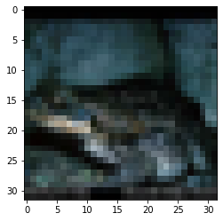

```python
img_path = '/home/d869321/PycharmProjects/neuralExamples/GANImages/real_frog9900.png'

img = image.load_img(img_path, target_size=(32,32))
img_tensor = image.img_to_array(img)
img_tensor = np.expand_dims(img_tensor, axis=0)
img_tensor /= 255.

plt.imshow(img_tensor[0])
```

... and here is a synthetic frog from the last iteration of the GAN network.

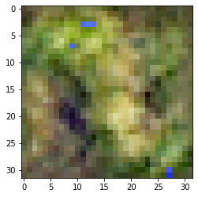

```python
img_path = '/home/d869321/PycharmProjects/neuralExamples/GANImages/generated_frog9900.png'

img = image.load_img(img_path, target_size=(32,32))
img_tensor = image.img_to_array(img)
img_tensor = np.expand_dims(img_tensor, axis=0)
img_tensor /= 255.

plt.imshow(img_tensor[0])
```